# Timing of trawling impacts

Compiled on Fri Oct 16 14:02:29 2020 by juanmayorga

# Methods

Let $C_t$ be the total labile carbon in the first meter of sediments impacted by bottom trawling. Assuming that the area and intensity of bottom trawling remains constant every year, we model the timeframe to depletion as:

$$C_{t + 1} = C_{t} + C_{A,t} - C_{L,t}$$

where $C_t$ is the labile carbon stock in time t, $C_{A,t}$ is the annual addition of labile carbon from external sources, and $C_{L,t}$ is the labile carbon lost each year. The labile carbon stock in year zero ($C_0$) is 38.4x10^9 Mg C and the annual addition of carbon from external sources amounts to 67.2x10^6 Mg C.

The annual carbon lost each year as a result of trawling is comprised of carbon that is lost by transport ($C_T$) and by remineralization ($C_R$), thus:

$$C_{L,t} = C_{T,t} + C_{R, t}$$

where

$$C_{T,t} = C_{d}(1-p_{crd})$$

and

$$C_{R,t} = C_{d}*\epsilon$$

where $p_{crd}$ is the fraction of disturbed sediment that resettles ($p_{crd} = 0.87$), and $\epsilon$ is the remineraliztion efficiency of disturbed sediments ($\epsilon = 0.35$). $C_{d}$ corresponds to the carbon that is disturbed each year by trawling which is defined as:

$$C_n = C_o*(p_d - p_d*p_{crd} - r_s)$$

where $C_0$ is the total labile carbon in year 0. This yields an annual deepening of the disturbed carbon layer of 0.0024 m yr^-1.

# Implementation

```r
n_steps <- 400

C_total_init <- 38427891520

C_add <- 67228000

e_rem <- 0.35

p_d <- 0.024

p_crd <- 0.87

sediment_recharge <- 0.0007

C_disturbed_init <- 1140000000
```

```r
C_total <- list()

C_total[[1]] <- C_total_init

C_disturbed <- list()

C_disturbed[[1]] <- C_disturbed_init

C_remin <- list()

C_remin[[1]] <- C_disturbed_init*0.35

C_trans <- list()

C_trans[[1]] <- C_disturbed_init*(1-p_crd)

d_new <- p_d - p_d*p_crd - sediment_recharge

for (i in 2:n_steps) {

  C_disturbed[[i]] <- C_disturbed[[i-1]] - C_remin[[i-1]] - C_trans[[i-1]] + C_add + C_total[[1]]*d_new

  C_remin[[i]] <- C_disturbed[[i]]*e_rem

  C_trans[[i]] <- C_disturbed[[i]]*(1-p_crd)

  C_total[[i]] <- C_total[[i-1]] + C_add - C_remin[[i-1]] - C_trans[[i-1]]

}
```

# Results

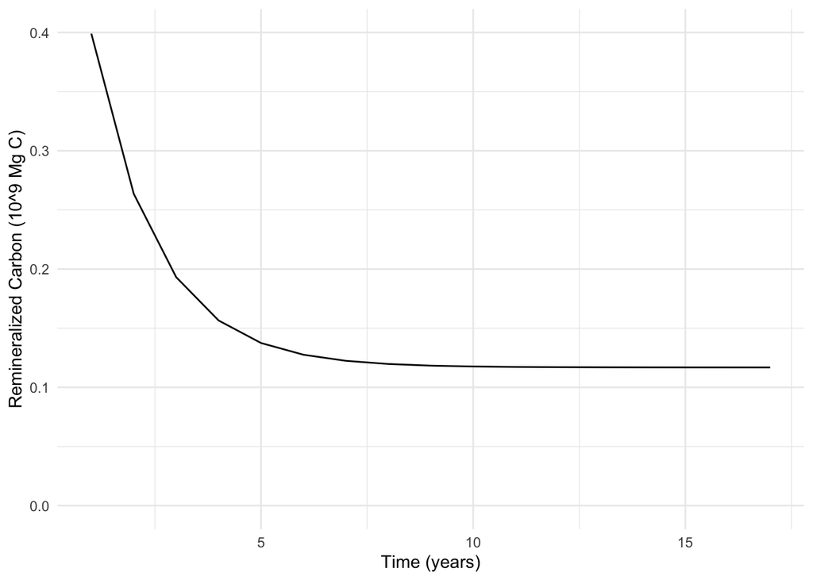

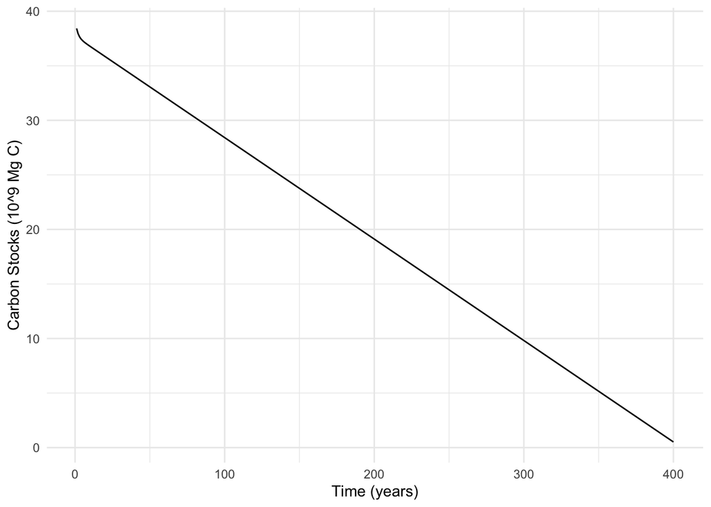